# Análisis de los supuestos

Luis Fernando Apáez Álvarez

13/11/2021

# Normalidad

Linealidad y homocedasticidad

Normalidad

Considerando el caso para la $n$ grande

Considerando el caso para la $n$ pequeña

Continuaremos con el ejemplo de los datos de la compañía Toluca.

## Linealidad y homocedasticidad

Para ello

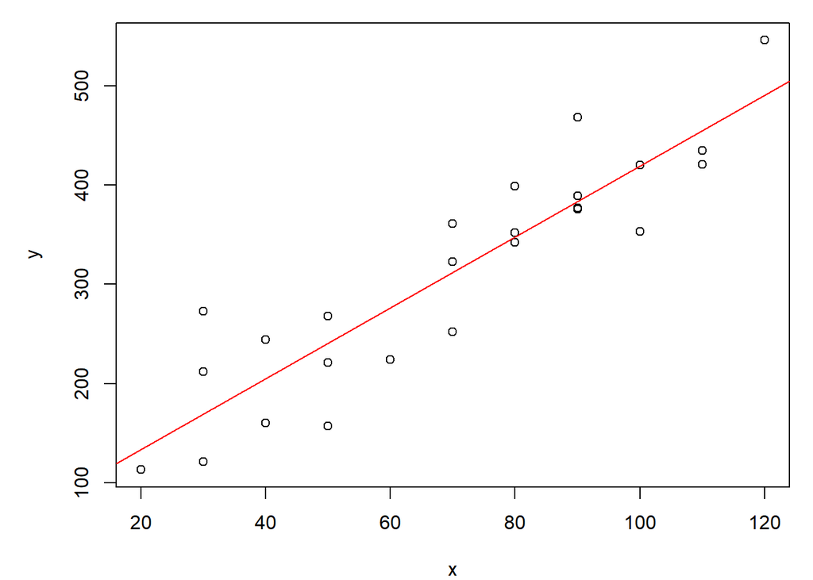

```r
library(latex2exp)

# Cargamos la librería con los datos
library(ALSM)

# Guardamos los datos
Datos = TolucaCompany

# Realizamos el ajuste del modelo
fit=lm(y~x, data=Datos)

# Graficamos el scatterplot inicial
par(mfrow=c(1,1))
par(mar=c(4, 5, 1, 1))
plot(Datos$x, Datos$y, xlab = TeX("$x$"), ylab=TeX("$y$") )
abline(fit, col="red")
```

Después revisamos los supuestos de linealidad y homocedasticidad utilizando las gráficas que trae por defecto `R`

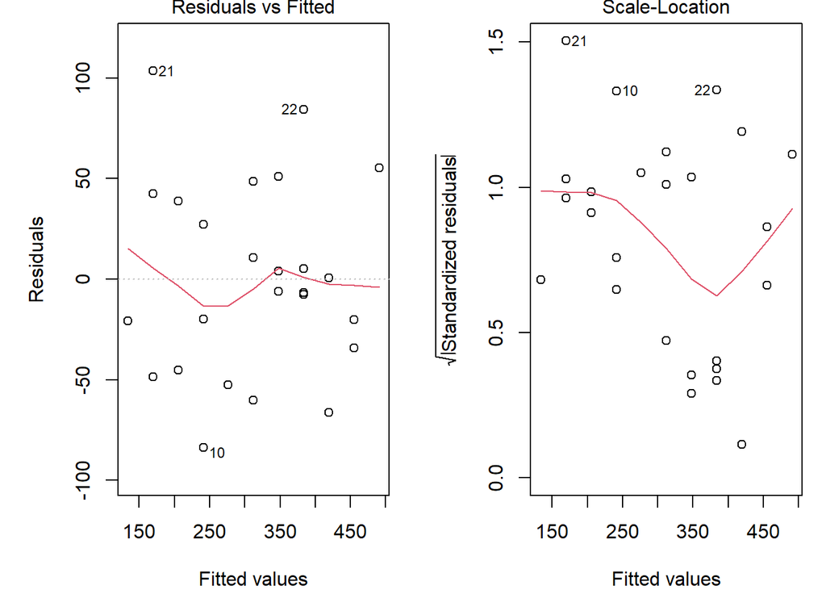

```r
#Gráficas
par(mar=c(4, 5, 1, 1))
par(mfrow=c(1,2))

# Linealidad
plot(fit, 1)

# Homocedasticidad
plot(fit, 3)
```

de donde no tenemos problema con la linealidad (y que en ejemplos anteriores habíamos indagado con más profundidad) ni problemas de homocedasticidad (a pesar de la curva que puede verse).

## Normalidad

Recordemos que para analizar el supuesto de la normalidad tenemos dos casos

1. Si $n$ es grande, efectuamos:
   - Q-Q plot de la distribución normal
   - Pruebas de hipótesis que contrastan:
     $$H_{0}: e_{st_{1}},\ldots,e_{st_{n}}\ \ \textrm{provienen de una normal vs} \ \ H_{a}: e_{st_{1}},\ldots,e_{st_{n}}\ \ \textrm{no provienen de una normal}$$
     donde se espera no rechazar $H_{0}$.
2. Si $n$ es pequeña, se sugiere probar la normalidad con $e_{st}$ , aunque también se sugiere realizar una Q-Q plot de una distribución $t_{n-3}$ (se espera que los puntos caigan sobre la diagonal) y realizar la prueba de *Kolmogorov-Smirnov* que contrasta

   $$H_{0}: e_{st_{1}},\ldots,e_{st_{n}}\ \ \textrm{provienen de una}\ \ t_{n-3}\ \ vs \ \ H_{a}: e_{st_{1}},\ldots,e_{st_{n}}\ \ \textrm{no provienen} \ \ t_{n-3}$$
   se espera no rechazar $H_{0}$

### Considerando el caso para la $n$ grande

Comencemos trabajando con el caso en que la $n$ es grande (a pesar que la $n$ de los datos no es tan grande)

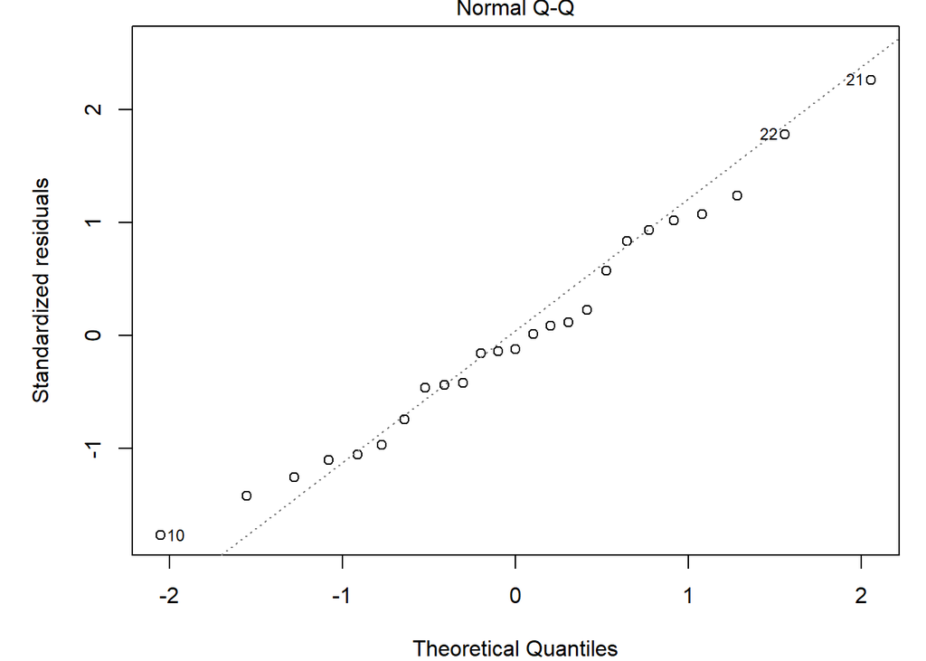

```r
#gráfica Q-Q plot directa de R

par(mar=c(4, 5, 1, 1))
par(mfrow=c(1,1))
plot(fit, 2)
```

donde podemos notar que los puntos caen sobre la diagonal, lo cual es justo lo que buscamos, teniendo así que no se encuentra evidencia en contra de la normalidad. Procedemos después a realizar las pruebas de hipótesis, donde

```r
# Utilizamos la librería broom para calcular los errores de forma automática
library(broom)

# Guardamos los errores en columnas de nuestro dataframe de los datos
Datosfit=augment(fit)
```

para después

```r
shapiro.test(Datosfit$.std.resid)
```

```
##
##  Shapiro-Wilk normality test
##
## data:  Datosfit$.std.resid
## W = 0.97861, p-value = 0.8563
```

donde no se está rechazando $H_{0}$, es decir, no se está encontrando evidencia en contra de la normalidad; utilizamos el paquete `nortest` el cual contiene muchas pruebas para analizar el supuesto de la normalidad, en el curso sólo se utilizará la `lillie` pues es una variante de la prueba de *Kolmogorov-Smirnov*

```r
library(nortest)
nortest::lillie.test(Datosfit$.std.resid)
```

```
##
##  Lilliefors (Kolmogorov-Smirnov) normality test
##
## data:  Datosfit$.std.resid
## D = 0.097207, p-value = 0.7851
```

tampoco se está rechazando $H_{0}$. Y finalmente

```r
library(normtest)
normtest::jb.norm.test(Datosfit$.std.resid)
```

```
##
##  Jarque-Bera test for normality
##
## data:  Datosfit$.std.resid
## JB = 0.73341, p-value = 0.5975
```

### Considerando el caso para la $n$ pequeña

Comenzamos por obtener los errores studentizados

```r
library(MASS)
ResStudent=studres(fit)
```

y después graficamos la Q-Q plot

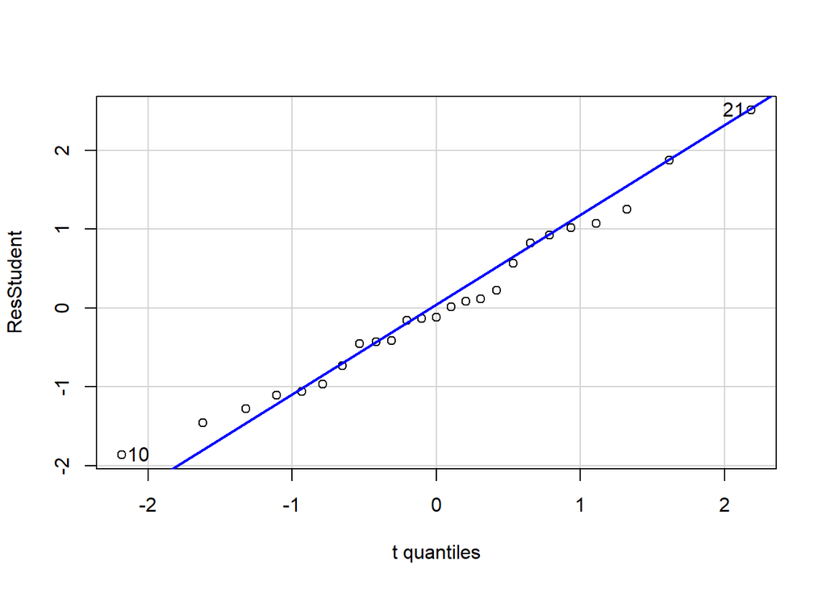

```
## [1] 21 10
```

```r
# Gráfica que trae por defecto R
qqPlot(ResStudent, dist="t", df=length(ResStudent)-3,  envelope=FALSE)
```

Analizando `dist="t", df=length(ResStudent)-3` tenemos que `dist` indica la distribución, que en nuestro caso es la $t$, en `df` especificamos los grados de libertad ($n-3$) y en `envelope` nos muestra una prueba de hipótesis (que por lo general no nos interesará mirar).

Procedemos después a relizar la prueba de *Kolmogorov-Smirnov*

```r
ks.test(ResStudent, "pt", length(ResStudent)-3)
```

```
##
##  One-sample Kolmogorov-Smirnov test
##
## data:  ResStudent
## D = 0.096752, p-value = 0.9556
## alternative hypothesis: two-sided
```

```r
# pt indica la distribución. Si quisieramos hacer la prueba sobre una
# distribución normal usaríamos pn
```

en la cual no se está rechazando $H_{0}$. En conjunto con la Q-Q plot mostrada y la prueba de hipótesis anterior, podemos ver nuevamente que no se presenta evidencia en contra de la normalidad.